# Test+a+Perceptual+Phenomenon+zh

### 统计学：检验心理学现象

在下方单元格中回答问题并执行相关代码，你可以 参考项目指导 并在正式提交前查看 [项目要求](https://review.udacity.com/#!/rubrics/305/view)。提交时请将 Jupyter notebook 导出成 HTML 或者 PDF 进行提交（File -> Download As）。

背景信息

在一个Stroop （斯特鲁普）任务中，参与者得到了一列文字，每个文字都用一种油墨颜色展示。参与者的任务是将文字的打印颜色大声说出来。这项任务有两个条件：一致文字条件，和不一致文字条件。在一致文字条件中，显示的文字是与它们的打印颜色匹配的颜色词，如“红色”、“蓝色”。在不一致文字条件中，显示的文字是与它们的打印颜色不匹配的颜色词，如“紫色”、“橙色”。在每个情况中，我们将计量说出同等大小的列表中的墨色名称的时间。每位参与者必须全部完成并记录每种条件下使用的时间。

调查问题

作为一般说明，请确保记录你在创建项目时使用或参考的任何资源。作为项目提交的一部分，你将需要报告信息来源。

(1) 我们的自变量是什么？因变量是什么？

--答案写这里--

自变量：一致文字条件，不一致文字条件

因变量：说出同等大小的列表中的墨色名称的时间

(2) 此任务的适当假设集是什么？你需要以文字和数学符号方式对假设集中的零假设和对立假设加以说明，并对数学符号进行定义。你想执行什么类型的统计检验？为你的选择提供正当理由（比如，为何该实验满足你所选统计检验的前置条件）。

--答案写这里--

#### 1.假设集：

$\mu$<sub>same</sub> ：一致文字条件下用时平均值(总体)

$\mu$<sub>diff</sub> ：不一致文字条件下用时平均值(总体)

零假设：一致文字条件下和不一致文字条件下用时均值相等。 用公式表示为：H<sub>0</sub>：$\mu$<sub>same</sub> = $\mu$<sub>diff</sub>

对立假设：一致文字条件下和不一致文字条件下用时均值不相等。 用公式表示为：H<sub>0</sub>：$\mu$<sub>same</sub> ！= $\mu$<sub>diff</sub>

#### 2.统计检验类型

使用t检验的双尾检验，$\alpha$=0.05.

#### 3.理由分析

(1)实验中总体参数未知，样本数据量<30。

(2)假设验证两个总体参数是否相等，因此选择双尾检验。

(3)样本数据是多个测试者参与的两种测试，因此属于配对样本t检验。

(4)t假设检验的前提条件：正态总体，方差未知，样本容量<30，对期望的检验。

z假设检验的前提条件：在方差已知的条件下对期望的检验。

**对比实验条件和t假设检验的前提条件，选择t检验。**

现在轮到你自行尝试 Stroop 任务了。前往此链接，其中包含一个基于 Java 的小程序，专门用于执行 Stroop 任务。记录你收到的任务时间（你无需将时间提交到网站）。现在下载此数据集，其中包含一些任务参与者的结果。数据集的每行包含一名参与者的表现，第一个数字代表他们的一致任务结果，第二个数字代表不一致任务结果。

(3) 报告关于此数据集的一些描述性统计。包含至少一个集中趋势测量和至少一个变异测量。

```python
# 在这里执行你的分析
import pandas as pd
import scipy.stats as stats

#加载数据
data = pd.read_csv('stroopdata.csv')
#数据基本参数描述
data.describe()
```

|  | Congruent | Incongruent |
| --- | --- | --- |
| count | 24.000000 | 24.000000 |
| mean | 14.051125 | 22.015917 |
| std | 3.559358 | 4.797057 |
| min | 8.630000 | 15.687000 |
| 25% | 11.895250 | 18.716750 |
| 50% | 14.356500 | 21.017500 |
| 75% | 16.200750 | 24.051500 |
| max | 22.328000 | 35.255000 |

```python
#求中位数
data.median()
```

```
Congruent      14.3565
Incongruent    21.0175
dtype: float64
```

```python
#求IQR
stats.iqr(data, axis = 0)
```

```
array([ 4.3055 ,  5.33475])
```

```python
#求极差
#一致文字条件数据极差
data.Congruent.ptp()
```

```
13.698000000000002
```

```python
#不一致文字条件数据极差
data.Incongruent.ptp()
```

```
19.568000000000001
```

### 描述性统计结果：

| 集中趋势测量 | Congruent | InCongruent |
| --- | --- | --- |
| 均值 | 14.0511 | 22.0159 |
| 中位数 | 14.3565 | 21.0175 |

| 变异测量 | Congruent | InCongruent |
| --- | --- | --- |
| 标准差 | 3.5594 | 4.7971 |
| IQR | 4.3055 | 5.33475 |
| 极差 | 13.6980 | 19.5680 |

(4) 提供显示样本数据分布的一个或两个可视化。用一两句话说明你从图中观察到的结果。

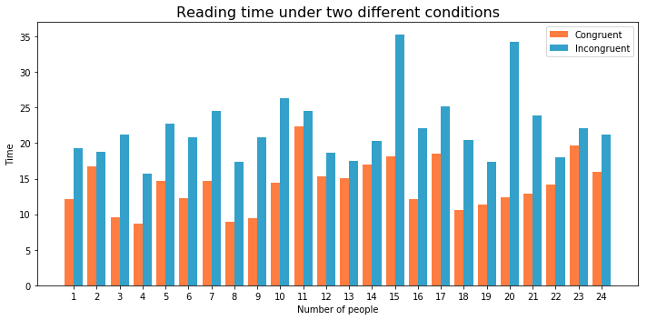

```python
#柱状图统计可视化
import numpy as np
import matplotlib.pyplot as plt

data.index = range(len(data.Congruent))
bar_width = 0.8
x_pos = np.arange(len(data.Congruent) * 2, step = 2)
plt.figure(figsize = [10,5])
plt.bar(x_pos, data['Congruent'], color = '#FF7D40', width = bar_width)
plt.bar(x_pos + bar_width, data['Incongruent'], color = '#33A1C9', width = bar_width)
plt.xticks(x_pos + bar_width / 2,data.index + 1)
plt.title('Reading time under two different conditions', fontsize=16)
plt.ylabel('Time')
plt.xlabel('Number of people')
plt.legend(data.columns)
plt.tight_layout()
plt.show()
```

--答案写这里--

由上图可以看出，每一位实验参与者对不一致文字条件下阅读用时都大于一致文字条件下的阅读用时。

(5) 现在，执行统计测试并报告你的结果。你的置信水平和关键统计值是多少？你是否成功拒绝零假设？对试验任务得出一个结论。结果是否与你的期望一致？

```python
# 在这里执行统计检验
#求标准偏差
np.std(data.Congruent - data.Incongruent,ddof=1)
```

```
4.8648269103590556
```

```python
#计算p-value:使用stats的配对样本t检验
stats.ttest_rel(data.Congruent,data.Incongruent,axis=0)
```

```
Ttest_relResult(statistic=-8.020706944109957, pvalue=4.1030005857111781e-08)
```

--答案写这里--

样本个数：24 均值偏差 = $\mu$<sub>same</sub> - $\mu$<sub>diff</sub> 也就是 $\mu$<sub>pian</sub> = 14.0511 - 22.0159 = -7.9648

标准偏差 = 4.8648

计算t统计量 = -8.0207 自由度 = 24 - 1 = 23 使用α=0.05，查表可知ν=23,p=0.025时临界值t=2.069 95%的置信区间：-7.965±2.069(4.865/√24) 即 (-10.02,-5.91) p-value 查表可知远小于0.0001

#### 结论

选择显著性水平α=0.05，即95%的置信水平，从计算结果看p值远小于0.05，因此拒绝零假设，接受对立假设，即一致文字条件下和不一致文字条件下阅读用时均值不相等，也就是文字条件是否一致对阅读时间有影响。